# R Notebook

## What’s different

Simple Linear Regression

y = bx + c

Multiple Linear Regression

y = b1x1 + b2x2 + b3x3 + c

- rather than explain the variation of y with one predictor (x), we’re going to all for multiple predictors (X)

## The Plan

- understand the business question
- build a simple linear model
- add in another predictor
  - categorical predictor (parallel slopes model)
- add in a futher predictor
  - continuous predictor
- look at interactions

### 1. The Data

```r
library(tidyverse)
library(janitor)
library(mosaicData)
```

```r
head(RailTrail)
```

|  | hightemp | lowtemp | avgtemp | spring | summer | fall | cloudcover | precip | volume | weekday | dayType |
| --- | --- | --- | --- | --- | --- | --- | --- | --- | --- | --- | --- |
| 1 | 83 | 50 | 66.5 | 0 | 1 | 0 | 7.6 | 0.00 | 501 | TRUE | weekday |
| 2 | 73 | 49 | 61.0 | 0 | 1 | 0 | 6.3 | 0.29 | 419 | TRUE | weekday |
| 3 | 74 | 52 | 63.0 | 1 | 0 | 0 | 7.5 | 0.32 | 397 | TRUE | weekday |
| 4 | 95 | 61 | 78.0 | 0 | 1 | 0 | 2.6 | 0.00 | 385 | FALSE | weekend |
| 5 | 44 | 52 | 48.0 | 1 | 0 | 0 | 10.0 | 0.14 | 200 | TRUE | weekday |
| 6 | 69 | 54 | 61.5 | 1 | 0 | 0 | 6.6 | 0.02 | 375 | TRUE | weekday |

```r
rail_trail <- RailTrail
```

```r
?RailTrail
```

Volume of Users of a Rail Trail

We’re going to build a model for `volume`.

Can we explain the variation in `volume` using other predictors?

Predictors:

- temperature (Fahrenheit)
- season
- cloudcover (0 to 10)
- precip (inches)
- weekday

Issues with Data in Raw Form:

- spring - fall are numbers rather than logical TRUE / FALSE
- some collinear predictors (we want our predictors to be independent)
  - temps
  - weekday/dayType
  - season

#### Variable Engineering

- drop collinear columns
- convert column types
- clean up column names

```r
railtrail_trim <- rail_trail %>%
  clean_names() %>%
  mutate(across(spring:fall, as.logical)) %>%
  select(-c(lowtemp, hightemp, fall, day_type))

head(railtrail_trim)
```

|  | avgtemp | spring | summer | cloudcover | precip | volume | weekday |
| --- | --- | --- | --- | --- | --- | --- | --- |
| 1 | 66.5 | FALSE | TRUE | 7.6 | 0.00 | 501 | TRUE |
| 2 | 61.0 | FALSE | TRUE | 6.3 | 0.29 | 419 | TRUE |
| 3 | 63.0 | TRUE | FALSE | 7.5 | 0.32 | 397 | TRUE |
| 4 | 78.0 | FALSE | TRUE | 2.6 | 0.00 | 385 | FALSE |
| 5 | 48.0 | TRUE | FALSE | 10.0 | 0.14 | 200 | TRUE |
| 6 | 61.5 | TRUE | FALSE | 6.6 | 0.02 | 375 | TRUE |

### Detect Perfect Collinearity

```r
alias(volume ~ .,
      data = RailTrail)
```

```
Model :
volume ~ hightemp + lowtemp + avgtemp + spring + summer + fall +
    cloudcover + precip + weekday + dayType

Complete :
               (Intercept) hightemp lowtemp spring summer cloudcover precip weekdayTRUE
avgtemp          0         1/2      1/2       0      0      0          0      0
fall             1           0        0      -1     -1      0          0      0
dayTypeweekend   1           0        0       0      0      0          0     -1
```

Check that we’ve removed the collinearity

```r
alias(volume ~ .,
      data = railtrail_trim)
```

```
Model :
volume ~ avgtemp + spring + summer + cloudcover + precip + weekday
```

Note: `alias` will only detect **perfect** matches

### Simple Linear Regression

| avgtemp | spring | summer | cloudcover | precip | volume | weekday |
| --- | --- | --- | --- | --- | --- | --- |
| 66.5 | FALSE | TRUE | 7.6 | 0.00 | 501 | TRUE |
| 61.0 | FALSE | TRUE | 6.3 | 0.29 | 419 | TRUE |
| 63.0 | TRUE | FALSE | 7.5 | 0.32 | 397 | TRUE |
| 78.0 | FALSE | TRUE | 2.6 | 0.00 | 385 | FALSE |
| 48.0 | TRUE | FALSE | 10.0 | 0.14 | 200 | TRUE |
| 61.5 | TRUE | FALSE | 6.6 | 0.02 | 375 | TRUE |
| 52.5 | TRUE | FALSE | 2.4 | 0.00 | 417 | TRUE |
| 52.0 | TRUE | FALSE | 0.0 | 0.00 | 629 | FALSE |
| 67.5 | FALSE | TRUE | 3.8 | 0.00 | 533 | FALSE |
| 62.0 | FALSE | TRUE | 4.1 | 0.00 | 547 | TRUE |

[output cut: 80 more lines]

Plot types:

- correlations
  - interested in **high**
- distribution of each
  - interested in **boxplots with different boxes for different categorical levels**
- scatter plots
  - interested in any **discernable patterns**

y = intercept + m_avg_temp * avg_temp

| avgtemp | spring | summer | cloudcover | precip | volume | weekday |
| --- | --- | --- | --- | --- | --- | --- |
| 66.5 | FALSE | TRUE | 7.6 | 0.00 | 501 | TRUE |
| 61.0 | FALSE | TRUE | 6.3 | 0.29 | 419 | TRUE |
| 63.0 | TRUE | FALSE | 7.5 | 0.32 | 397 | TRUE |
| 78.0 | FALSE | TRUE | 2.6 | 0.00 | 385 | FALSE |
| 48.0 | TRUE | FALSE | 10.0 | 0.14 | 200 | TRUE |
| 61.5 | TRUE | FALSE | 6.6 | 0.02 | 375 | TRUE |
| 52.5 | TRUE | FALSE | 2.4 | 0.00 | 417 | TRUE |
| 52.0 | TRUE | FALSE | 0.0 | 0.00 | 629 | FALSE |
| 67.5 | FALSE | TRUE | 3.8 | 0.00 | 533 | FALSE |
| 62.0 | FALSE | TRUE | 4.1 | 0.00 | 547 | TRUE |

[output cut: 80 more lines]

#### Goodness of fit metrics

- $r^2$: coefficient of determination (1 = perfect, 0 = perfectly imperfect)
- standard error in the residuals
  - how far are the residuals from the line
  - how far on average do the fitted values differ from the measured values (same units as)

```r
model <- lm(volume ~ avgtemp, railtrail_trim)
```

```r
summary(model)
```

```
Call:
lm(formula = volume ~ avgtemp, data = railtrail_trim)

Residuals:
    Min      1Q  Median      3Q     Max
-237.53  -80.00    8.49   55.14  326.67

Coefficients:
            Estimate Std. Error t value Pr(>|t|)
(Intercept)   99.602     63.474   1.569     0.12
avgtemp        4.802      1.084   4.428 2.72e-05 ***
---
Signif. codes:  0 ‘***’ 0.001 ‘**’ 0.01 ‘*’ 0.05 ‘.’ 0.1 ‘ ’ 1

Residual standard error: 115.9 on 88 degrees of freedom
Multiple R-squared:  0.1822,    Adjusted R-squared:  0.1729
F-statistic: 19.61 on 1 and 88 DF,  p-value: 2.723e-05
```

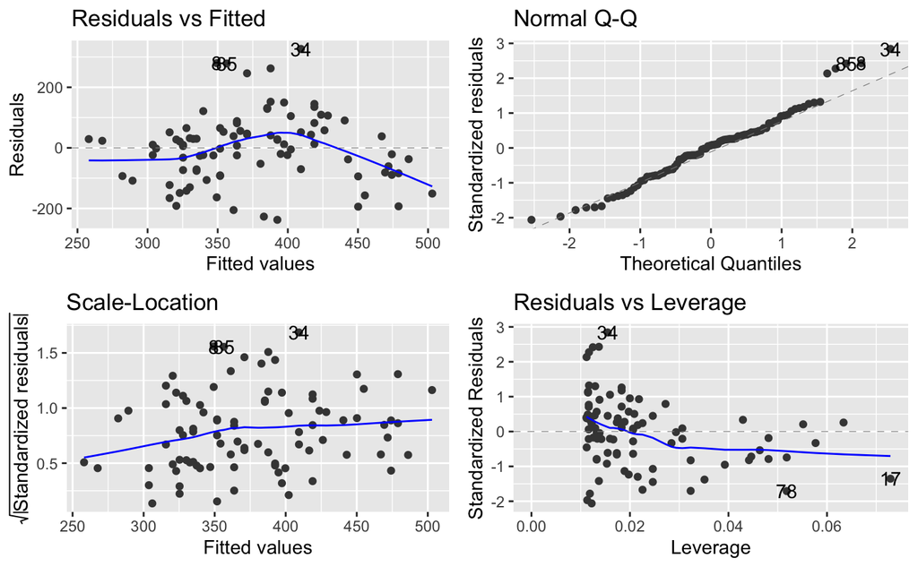

We can now explain 0.18 of the variation of the volume is due to avg temp (not a lot)

Residual standard error is high (over 100 for measurements that only go up to 500)

How do we improve our model?? ADD PREDICTORS

#### Add predictor

Visualise relationship with a plot

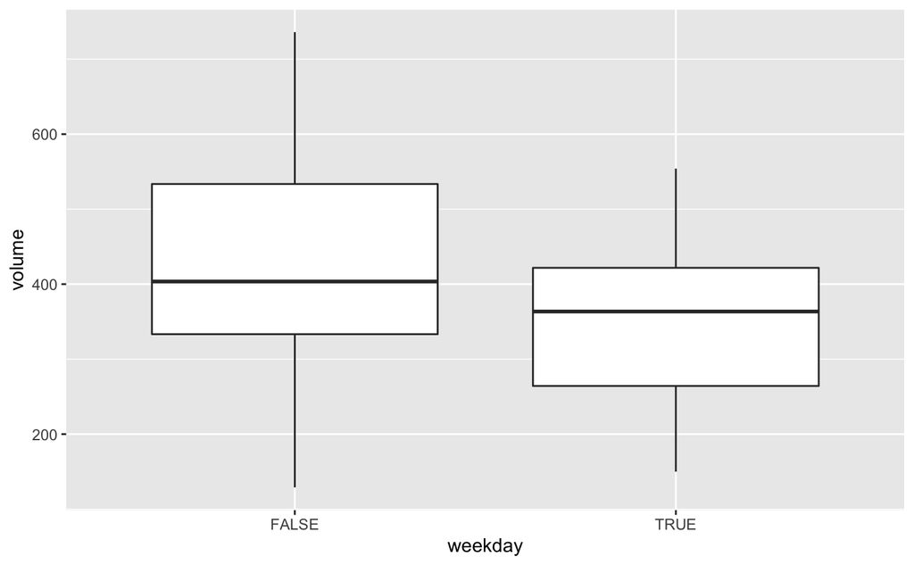

```r
railtrail_trim %>%
  ggplot(aes(x = weekday,
             y = volume))+
  geom_boxplot()
```

```r
railtrail_trim %>%
  summarise(cor = cor(weekday, volume))
```

| cor |
| --- |
| -0.2932675 |

A value of -0.3 suggests that volume and weekday are related (there is a dependency)

y = intercept + (b_avg_temp * avg_temp) + (b_weekday * weekday)

```r
model_temp_wday
```

```
Call:
lm(formula = formula, data = railtrail_trim)

Coefficients:
(Intercept)      avgtemp  weekdayTRUE
    163.022        4.541      -70.320
```

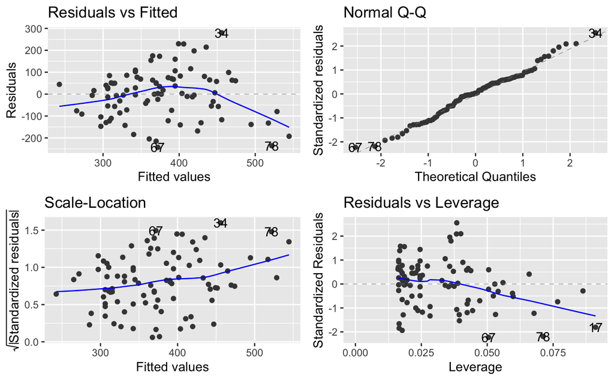

```r
autoplot(model_temp_wday)
```

```r
summary(model_temp_wday)
```

```
Call:
lm(formula = formula, data = railtrail_trim)

Residuals:
    Min      1Q  Median      3Q     Max
-242.92  -75.72    3.15   66.90  280.06

Coefficients:
            Estimate Std. Error t value Pr(>|t|)
(Intercept)  163.022     65.428   2.492  0.01461 *
avgtemp        4.541      1.050   4.323 4.08e-05 ***
weekdayTRUE  -70.320     25.566  -2.751  0.00724 **
---
Signif. codes:  0 ‘***’ 0.001 ‘**’ 0.01 ‘*’ 0.05 ‘.’ 0.1 ‘ ’ 1

Residual standard error: 111.8 on 87 degrees of freedom
Multiple R-squared:  0.2476,    Adjusted R-squared:  0.2303
F-statistic: 14.32 on 2 and 87 DF,  p-value: 4.214e-06
```

We get a slight improvement on $r^2$: 0.18 - 0.25. Our model including avgtemp and weekday can explain 0.25 of the total variation of volume

Slight reduction in RSE too: 115 - 111

Task - 2 mins How should we interpret the value of the coefficient for weekdayTRUE?

On average there were 70 fewer people on the trail on weekdays compared to the weekends (holding avgtemp constant)

Visualising the “parallel slopes”

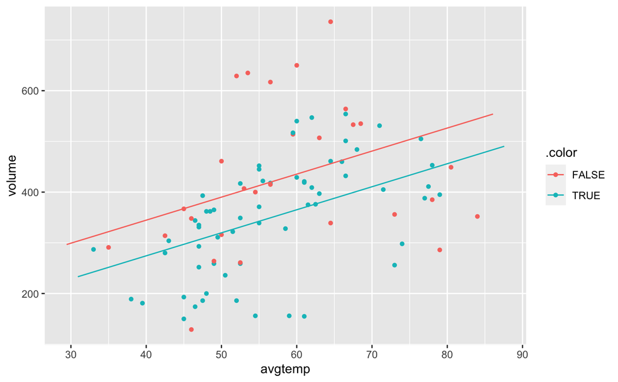

Why are there two lines?

2 conditions (2 category levels for weeekday: TRUE or FALSE)

If we had 7 variables, we’d get 7 * 2 lines: TRUE or FALSE

volume = intercept + (b_avg_temp * avg_temp) + (b_weekday * weekday)

rearranged:

when weekday is FALSE:

volume = intercept + (b_avg_temp * avg_temp) + 0

#### Add another predictor

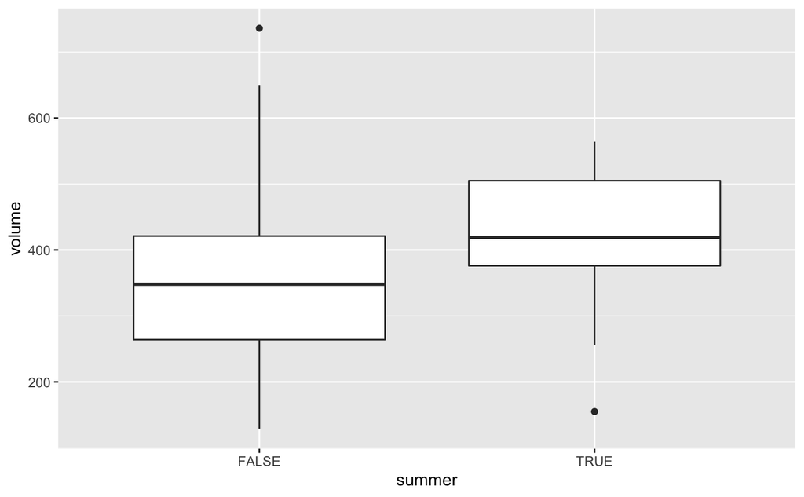

```r
railtrail_trim %>%
  ggplot(aes(x = summer,
             y = volume))+
  geom_boxplot()
```

```r
railtrail_trim %>%
  summarise(cor = cor(summer, volume))
```

| cor |
| --- |
| 0.227417 |

```r
model_temp_wday_summer
```

```
Call:
lm(formula = volume ~ avgtemp + weekday + summer, data = railtrail_trim)

Coefficients:
(Intercept)      avgtemp  weekdayTRUE   summerTRUE
     71.376        6.387      -66.958      -59.977
```

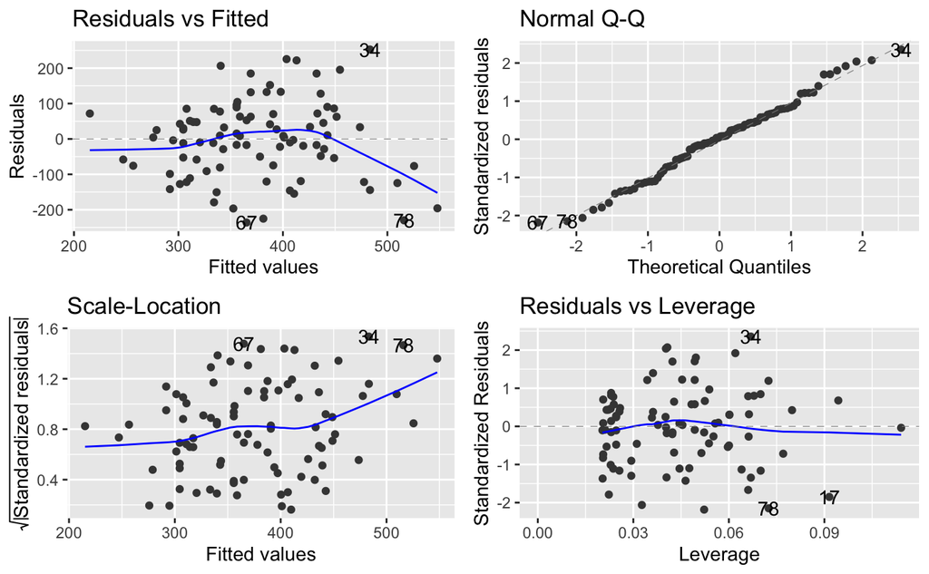

```r
autoplot(model_temp_wday_summer)
```

```r
summary(model_temp_wday_summer)
```

```
Call:
lm(formula = volume ~ avgtemp + weekday + summer, data = railtrail_trim)

Residuals:
     Min       1Q   Median       3Q      Max
-236.165  -75.448    6.184   68.496  252.680

Coefficients:
            Estimate Std. Error t value Pr(>|t|)
(Intercept)   71.376     90.336   0.790 0.431630
avgtemp        6.387      1.639   3.898 0.000192 ***
weekdayTRUE  -66.958     25.505  -2.625 0.010244 *
summerTRUE   -59.977     41.052  -1.461 0.147662
---
Signif. codes:  0 ‘***’ 0.001 ‘**’ 0.01 ‘*’ 0.05 ‘.’ 0.1 ‘ ’ 1

Residual standard error: 111.1 on 86 degrees of freedom
Multiple R-squared:  0.2659,    Adjusted R-squared:  0.2402
F-statistic: 10.38 on 3 and 86 DF,  p-value: 6.714e-06
```

We’re not going to include summer (at this point)

If we were, look more into what we’re about to do - looking at interactions (it depends)

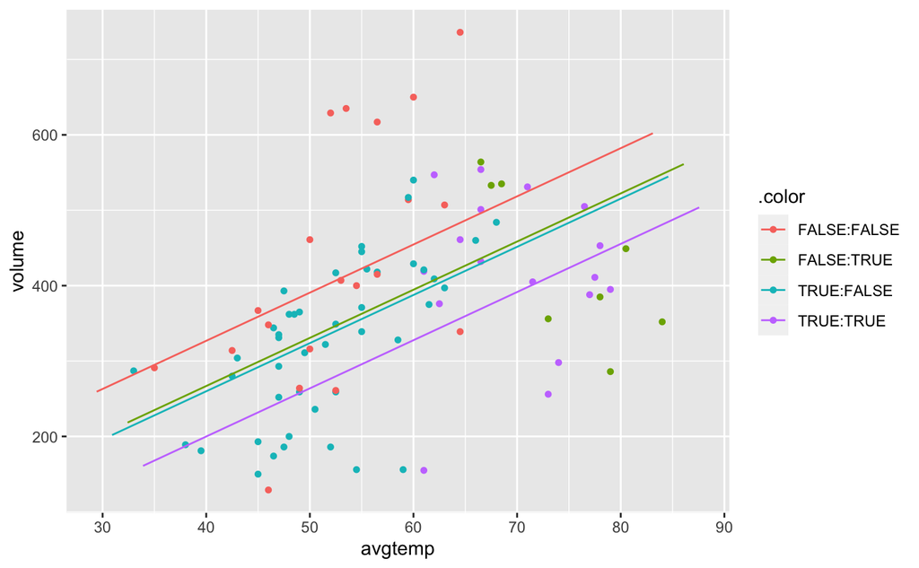

```r
plotModel(model_temp_wday_summer)
```

### Interactions

Sometimes there will be a **dependency** on the ‘independent’ predictors

Back to the second model with avg_temp and weekday

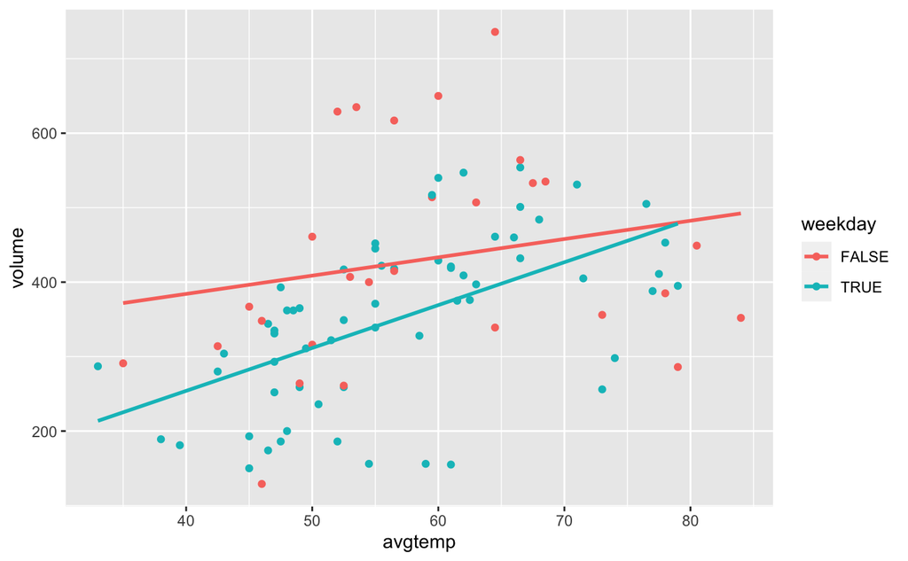

```r
railtrail_trim %>%
  ggplot(aes(x = avgtemp,
             y = volume,
             colour = weekday))+
  geom_point()+
  geom_smooth(method = "lm", se = FALSE)
```

slopes = avgtemp vs volume

the lines of best fit (“lm”) are different for avgtemp vs volume for different weekday levels

volume ~ avgtemp + weekday + avgtemp:weekday

volume depends on avgtemp, weekday and the dependency of avgtemp on weekday

It depends…

- what does an increase in avgtemp have on volume?
  - it depends on whether it’s a weekday or not

```r
model_temp_wday_interTW <- lm(volume ~ avgtemp + weekday + avgtemp:weekday,
                              data = railtrail_trim)

summary(model_temp_wday_interTW)
```

```
Call:
lm(formula = volume ~ avgtemp + weekday + avgtemp:weekday, data = railtrail_trim)

Residuals:
     Min       1Q   Median       3Q      Max
-269.906  -78.862    2.064   68.190  291.641

Coefficients:
                    Estimate Std. Error t value Pr(>|t|)
(Intercept)          285.887    103.390   2.765  0.00696 **
avgtemp                2.457      1.718   1.431  0.15619
weekdayTRUE         -262.193    128.181  -2.045  0.04386 *
avgtemp:weekdayTRUE    3.300      2.161   1.527  0.13040
---
Signif. codes:  0 ‘***’ 0.001 ‘**’ 0.01 ‘*’ 0.05 ‘.’ 0.1 ‘ ’ 1

Residual standard error: 111 on 86 degrees of freedom
Multiple R-squared:  0.2675,    Adjusted R-squared:  0.2419
F-statistic: 10.47 on 3 and 86 DF,  p-value: 6.115e-06
```

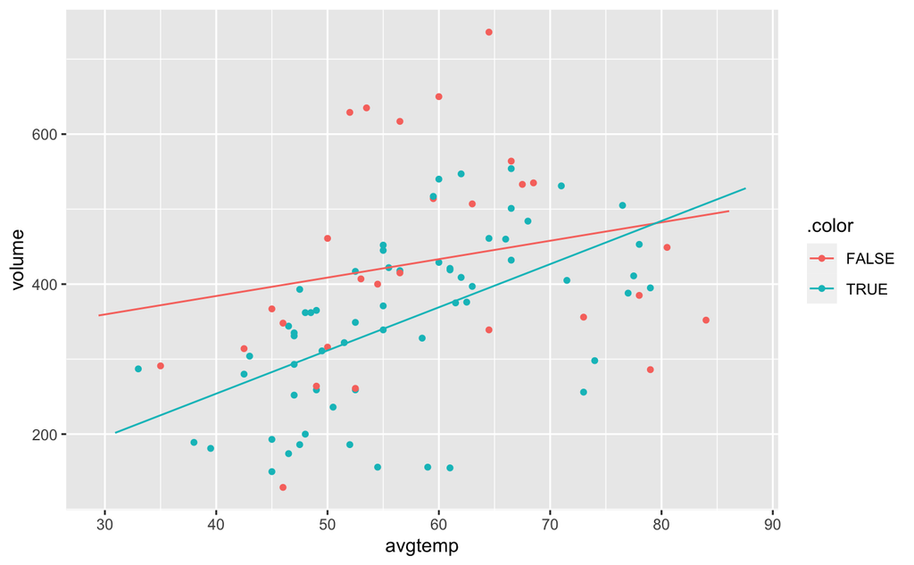

```r
plotModel(model_temp_wday_interTW)
```

IF weekday is TRUE:

volume = 285 + 2.45 * avgtemp - 262 + 3.3 * avgtemp

```r
285 + 2.45 * 50 - 262 + 3.3 * 50
```

```
[1] 310.5
```

IF weekday is FALSE:

volume = 285 + 2.45 * avgtemp

```r
285 + 2.45 * 50
```

```
[1] 407.5
```

### Add cloudcover to the model

Forget about our continuous and categorical interaction for the moment

volume = b_avg_temp * avg_temp + b_weekday * weekday + b_cloudcover * cloudcover

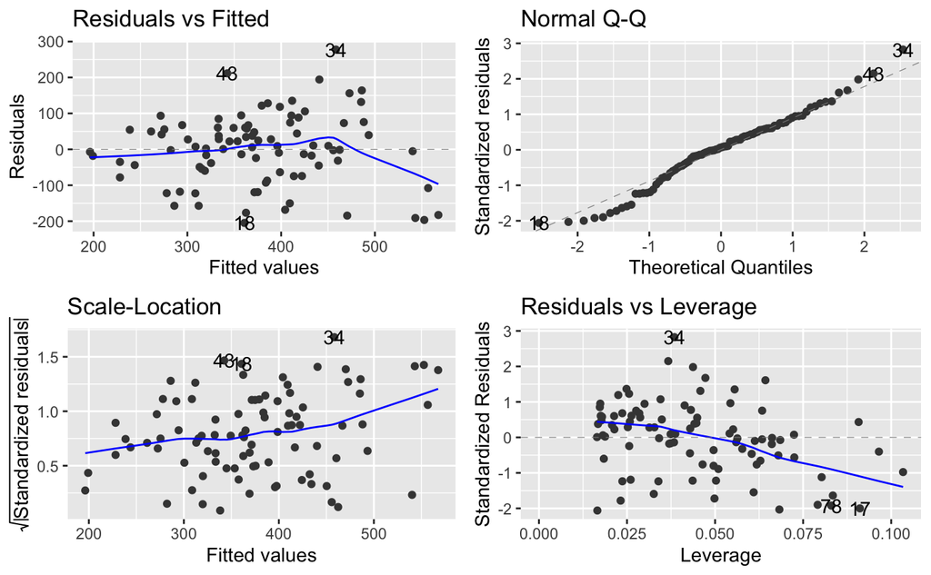

```r
model3_terms <- lm(volume ~ avgtemp + weekday + cloudcover,
                   data = railtrail_trim)

autoplot(model3_terms)
```

```r
summary(model3_terms)
```

```
Call:
lm(formula = volume ~ avgtemp + weekday + cloudcover, data = railtrail_trim)

Residuals:
     Min       1Q   Median       3Q      Max
-204.803  -58.375    6.594   60.178  277.581

Coefficients:
            Estimate Std. Error t value Pr(>|t|)
(Intercept) 200.1022    59.1826   3.381  0.00109 **
avgtemp       5.2461     0.9536   5.502 3.81e-07 ***
weekdayTRUE -47.9480    23.4061  -2.049  0.04356 *
cloudcover  -16.0115     3.3952  -4.716 9.21e-06 ***
---
Signif. codes:  0 ‘***’ 0.001 ‘**’ 0.01 ‘*’ 0.05 ‘.’ 0.1 ‘ ’ 1

Residual standard error: 100.3 on 86 degrees of freedom
Multiple R-squared:  0.4022,    Adjusted R-squared:  0.3814
F-statistic: 19.29 on 3 and 86 DF,  p-value: 1.185e-09
```

A bit more progress with this model

- $r^2$: increased from 25 - 40 which explains 40% of variation in volume
- RSE: reduced from 110 - 100 users

Interpreting our results:

For a 1 degree increase in temperature, we expect 5.2 more users in volume on the trail (holding all other variables constant)

For a 40 degree, 5 cloudcover weekeday, we expect:

```r
200 - 47.95 + 5.25 * 40 + 5 * (-16)
```

```
[1] 282.05
```

282 users

### Interactions between continuous predictors

Task - 5 mins Add precip (daily precipitation in inches) into the regression model. Perform diagnostics, and if you find that precip is a significant predictor, interpret its fitted coefficient.

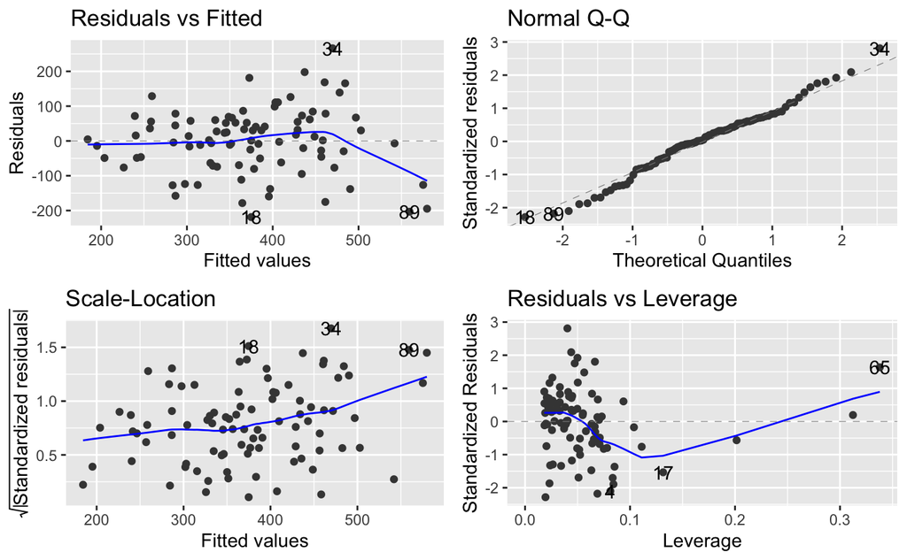

```r
model_w_precip <- lm(volume ~ avgtemp + weekday + cloudcover + precip,
                     data = railtrail_trim)

autoplot(model_w_precip)
```

```r
summary(model_w_precip)
```

```
Call:
lm(formula = volume ~ avgtemp + weekday + cloudcover + precip,
    data = railtrail_trim)

Residuals:
     Min       1Q   Median       3Q      Max
-218.881  -58.924    3.428   57.285  266.250

Coefficients:
             Estimate Std. Error t value Pr(>|t|)
(Intercept)  155.0024    59.4574   2.607 0.010787 *
avgtemp        5.8743     0.9485   6.193 2.02e-08 ***
weekdayTRUE  -45.8821    22.5943  -2.031 0.045412 *
cloudcover   -12.8294     3.4783  -3.688 0.000397 ***
precip      -117.5681    43.2329  -2.719 0.007928 **
---
Signif. codes:  0 ‘***’ 0.001 ‘**’ 0.01 ‘*’ 0.05 ‘.’ 0.1 ‘ ’ 1

Residual standard error: 96.72 on 85 degrees of freedom
Multiple R-squared:  0.4501,    Adjusted R-squared:  0.4242
F-statistic: 17.39 on 4 and 85 DF,  p-value: 1.849e-10
```

volume = intercept + b_avg_temp * avg_temp + b_weekday * weekday + b_cloudcover * cloudcover + b_precip * precip

for a 1 inch increase in rainfall, we’d expect 117.5 fewer users on the trail (as rainfall increases, volume decreases)

#### Incorporate the interaction between avgtemp and precip

volume on the railtrail is dependent on the avgtemp, but that relationship might change due to whether it’s raining or not.

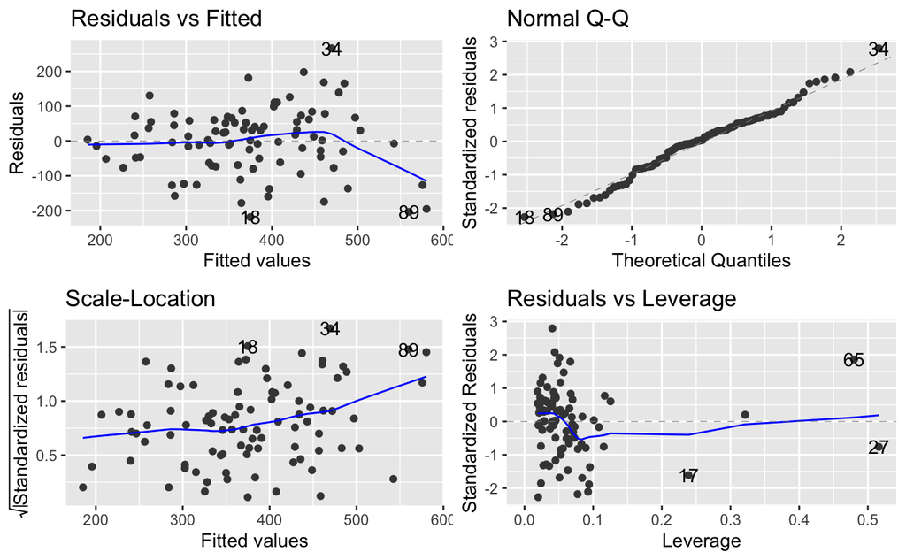

```r
model_w_precip_with_IT <- lm(volume ~ avgtemp + weekday + cloudcover + precip + avgtemp:precip,
                             data = railtrail_trim)

autoplot(model_w_precip_with_IT)
```

```r
summary(model_w_precip_with_IT)
```

```
Call:
lm(formula = volume ~ avgtemp + weekday + cloudcover + precip +
    avgtemp:precip, data = railtrail_trim)

Residuals:
     Min       1Q   Median       3Q      Max
-218.775  -59.164    3.183   57.361  266.189

Coefficients:
                Estimate Std. Error t value Pr(>|t|)
(Intercept)     153.9280    63.9007   2.409 0.018189 *
avgtemp           5.8964     1.0598   5.564 3.08e-07 ***
weekdayTRUE     -45.8527    22.7365  -2.017 0.046921 *
cloudcover      -12.8866     3.6984  -3.484 0.000786 ***
precip         -100.8213   353.3547  -0.285 0.776097
avgtemp:precip   -0.2335     4.8893  -0.048 0.962023
---
Signif. codes:  0 ‘***’ 0.001 ‘**’ 0.01 ‘*’ 0.05 ‘.’ 0.1 ‘ ’ 1

Residual standard error: 97.29 on 84 degrees of freedom
Multiple R-squared:  0.4501,    Adjusted R-squared:  0.4173
F-statistic: 13.75 on 5 and 84 DF,  p-value: 8.34e-10
```

Actually, adding in this interaction has **reduced** the significance of some terms in our model.

```r
volume_estimate
```

```
[1] 275.5 221.1 166.7
```

Check the interaction plots to see if there is an effect

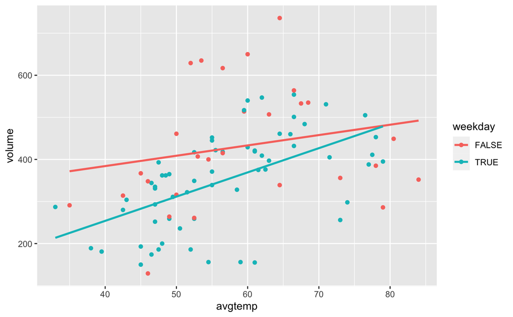

```r
railtrail_trim %>%
  ggplot(aes(x = avgtemp,
             y = volume,
             colour = weekday))+
  geom_point()+
  geom_smooth(method = "lm", se = FALSE)
```

We can’t use the above for 2 continuous variables

We need to use a coplot

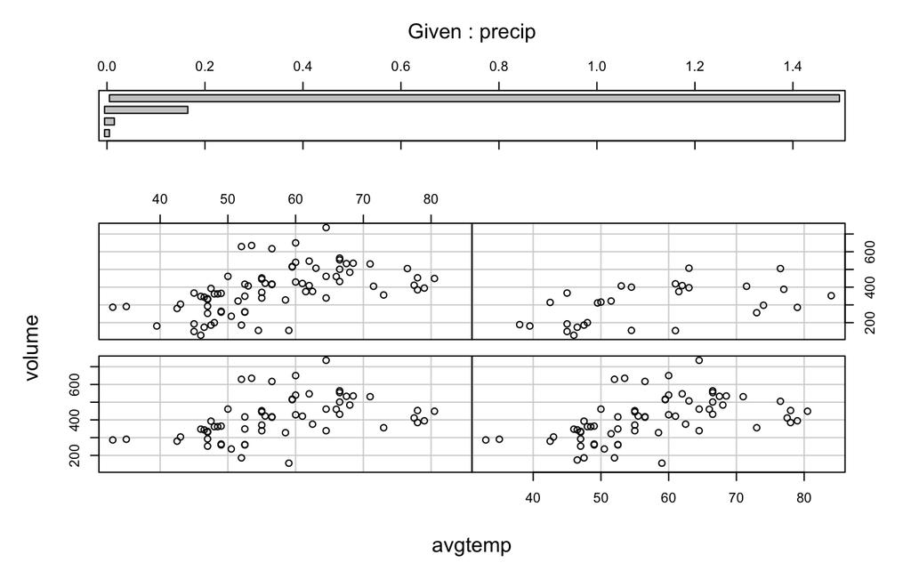

```r
coplot(volume ~ avgtemp | precip,
       data = railtrail_trim)
```

Add trendlines

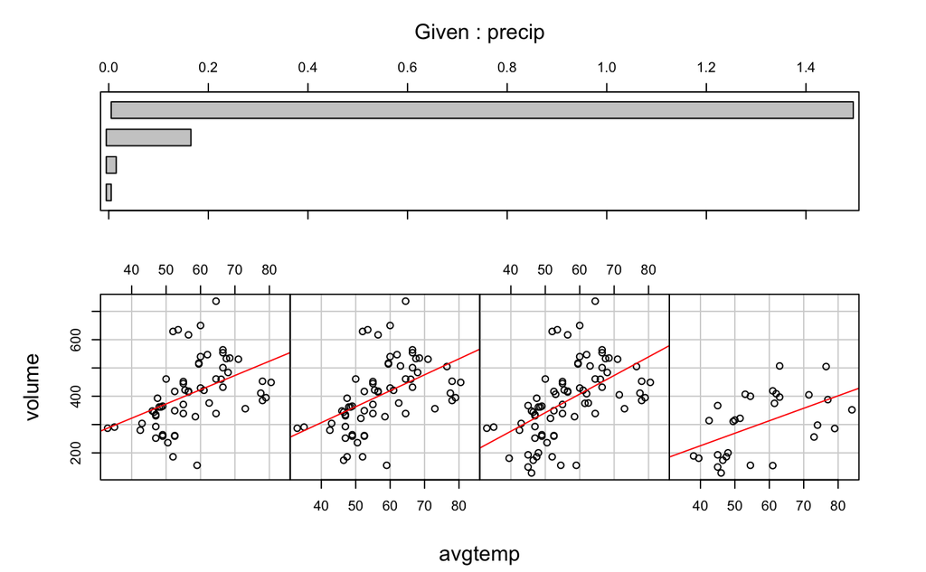

```r
coplot(volume ~ avgtemp | precip,
       data = railtrail_trim,
       rows = 1,
       panel = function(x, y, ...) {
         points(x, y)
         abline(lm(y ~ x), col = "red")
       })
```

The relationship between volume and average temperature is the ‘same’ for every level of precipitation.

It is **not likely** that there is a significant interaction betweem avgtemp and precipitation.

```r
library(modelr)
```

```r
railtrail_trim %>%
  add_predictions(model = model_w_precip)
```

| avgtemp | spring | summer | cloudcover | precip | volume | weekday | pred |
| --- | --- | --- | --- | --- | --- | --- | --- |
| 66.5 | FALSE | TRUE | 7.6 | 0.00 | 501 | TRUE | 402.2604 |
| 61.0 | FALSE | TRUE | 6.3 | 0.29 | 419 | TRUE | 352.5350 |
| 63.0 | TRUE | FALSE | 7.5 | 0.32 | 397 | TRUE | 345.3614 |
| 78.0 | FALSE | TRUE | 2.6 | 0.00 | 385 | FALSE | 579.8445 |
| 48.0 | TRUE | FALSE | 10.0 | 0.14 | 200 | TRUE | 246.3350 |
| 61.5 | TRUE | FALSE | 6.6 | 0.02 | 375 | TRUE | 383.3668 |
| 52.5 | TRUE | FALSE | 2.4 | 0.00 | 417 | TRUE | 386.7326 |
| 52.0 | TRUE | FALSE | 0.0 | 0.00 | 629 | FALSE | 460.4681 |
| 67.5 | FALSE | TRUE | 3.8 | 0.00 | 533 | FALSE | 502.7686 |
| 62.0 | FALSE | TRUE | 4.1 | 0.00 | 547 | TRUE | 420.7288 |

[output cut: 80 more lines]

```r
prediction
```

```
[1] 279.9469 221.1628 162.3788
```